# San Joaquin Canopy Structure

{Hazel Vaquero}

2023-12-14

# Overview

Lidar, or Light Detection And Ranging, is one of many remote sensing methods that has the ability to penetrate thick vegetation to gather surface elevation data[^1]. It plays an important role in estimating tree canopy structure (tree height) and can reduce the funds and time for on-the-ground field surveys[^2].

In this project I will study the canopy structure (tree height) at the San Joaquin Experimental Range in California. I will compare the tree height estimates of Lidar data NEON to on-the-ground field surveys. Thus providing evidence of the benefit of using Lidar as a replacement to field surveys.

## Steps

- create canopy height model (CHM)
- extract raster data
- data wrangling
- map creation

## Data

**Lidar data**

The National Science Foundation’s [National Ecological Observatory Network (NEON)](https://www.neonscience.org/about) collects standardized, open-access ecological data at 81 freshwater and terrestrial field sites across the country. They periodically collect Lidar data at the sites and have an extensive database of on-the-ground surveys.

This project requires their data on: - Digital surface model (DSM) `SJER2013_DSM.tif` - Digital terrain model (DTM) `SJER2013_DTM.tif` - Vegetation survey location `SJERPlotCentroids_Buffer.shp` - Measures for individual data `D17_2013_vegStr.csv`

This project is based on [materials](https://www.neonscience.org/resources/learning-hub/tutorials/introduction-light-detection-and-ranging-lidar-explore-point) developed by Edmund Hart, Leah Wasser, and Donal O’Leary for NEON.

## Prepare Data

Load all necessary packages and data.

```r
# Libraries
library(terra)
library(sf)
library(tidyverse)
library(tmap)
library(here)

# Keep all character strings as characters
options(stringsAsFactors=FALSE)

# Data import
# Lidar
# digital surface model (DSM)
dsm <- rast("data/SJER2013_DSM.tif")

# digital terrain model (DTM)
dtm <- rast("data/SJER2013_DTM.tif")

# read in vegetation survey location
veg_loc <- st_read("data/PlotCentroids/SJERPlotCentroids_Buffer.shp")
# read in vegetation data
veg_surveys <- read.csv("data/VegetationData/D17_2013_vegStr.csv")
```

An important step before the analysis is to determine if the the DSM and DTM data have the same resolution, position, and extent.

```r
# check DSM and DTM for equal resolution, position, and extent
test_raster <- c(dsm, dtm)
```

The next step is to create the canopy height model (CHM). This will represent the height of all objects.

```r
# Canopy height model
chm <- dsm - dtm
```

A map of the varying heights can be produced to visualize the CHM.

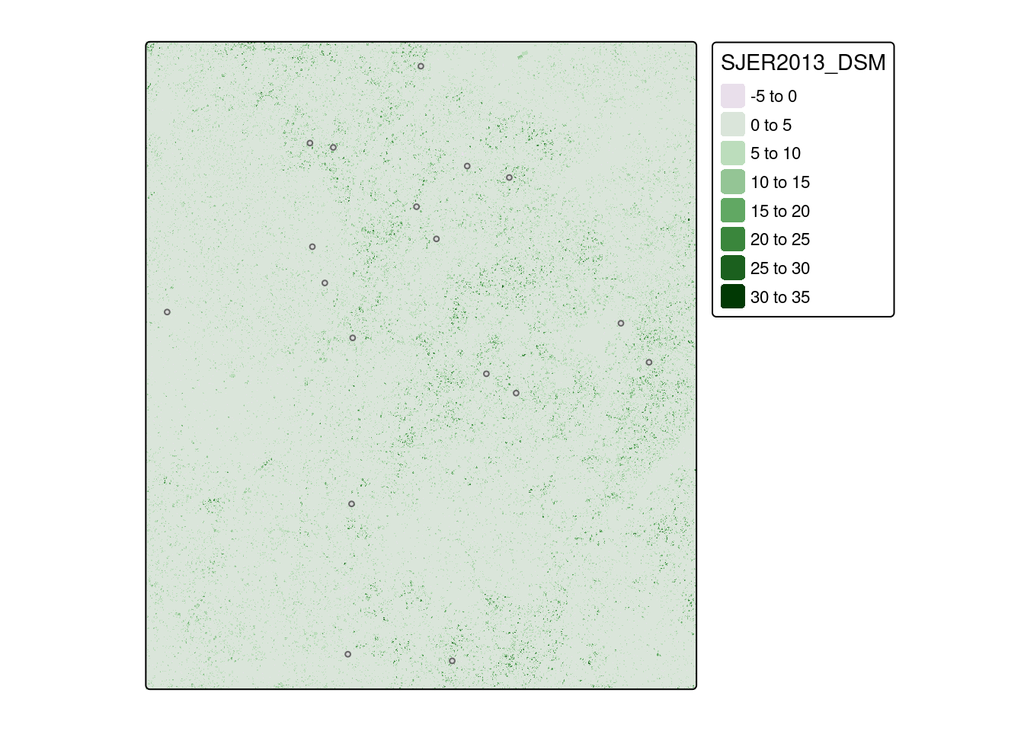

```r
# test if the vegetation location CRS matches the Lidar CRS
#st_crs(veg_loc) == st_crs(chm)

# Generate plot
tm_shape(chm) +
  tm_raster() +
  tm_shape(veg_loc) +
  tm_polygons()
```

The maximum tree height for Lidar and on-the-ground field surveys are calculated and joined to be compared.

```r
# Maximum tree height of field survey
veg_surveys <- veg_surveys %>%
  group_by(plotid) %>%
  summarise("survey_height" = max(stemheight, na.rm = TRUE))

# Maximum tree height of CHM
extract_chm_height <- terra::extract(chm, veg_loc, fun = max) %>%
  rename(chm_height = SJER2013_DSM) %>%
  select(chm_height)

# Join tree height estimates
heights <- cbind(veg_loc, extract_chm_height) %>%
  left_join(.,veg_surveys, by = c("Plot_ID" = "plotid"))
```

## Visualization

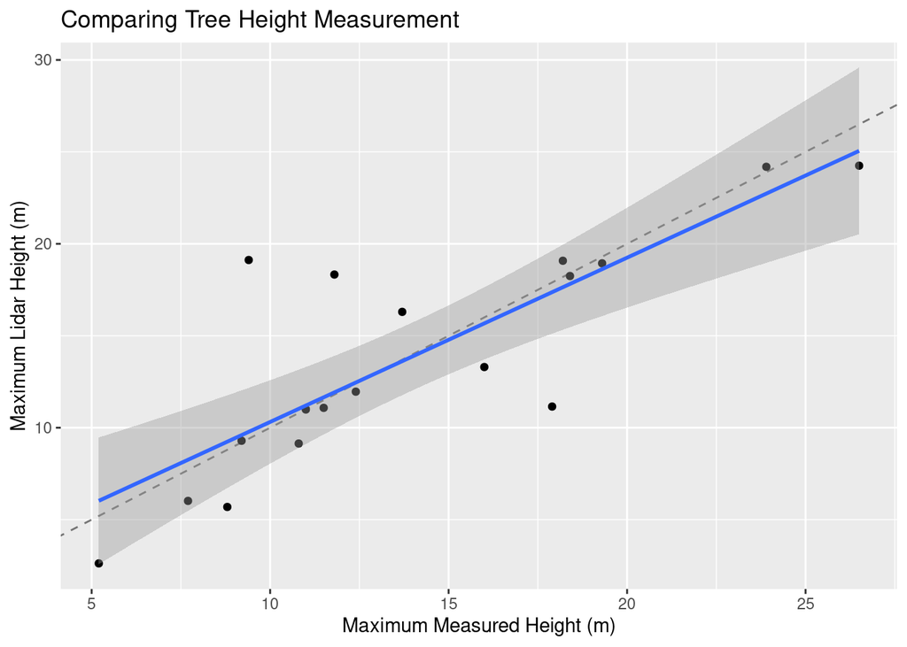

```r
ggplot(heights, aes(y=chm_height, x= survey_height)) +
  geom_abline(slope=1, intercept=0, alpha=.5, lty=2) +
  geom_point() +
  geom_smooth(method = lm) + # add regression line and confidence interval
  ggtitle("Comparing Tree Height Measurement") +
  xlab("Maximum Measured Height (m)") +
  ylab("Maximum Lidar Height (m)")
```

Lidar estimates are somewhat on par with the measured tree heights. Except it tends to overestimate tree heights for smaller trees. And underestimate tree heights for larger trees. This could be due to humar errors in on-the-ground tree observation. Or Lidar is misjudging the elevation of the ground or misidentifying tree canopies.

[^1]: Lidar. Lidar | NSF NEON | Open Data to Understand our Ecosystems. (n.d.). https://www.neonscience.org/data-collection/lidar
[^2]: Frank Hanssen, David N. Barton, Zander S. Venter, Megan S. Nowell, Zofie Cimburova, Utilizing LiDAR data to map tree canopy for urban ecosystem extent and condition accounts in Oslo, Ecological Indicators, Volume 130,2021, 108007, ISSN 1470-160X, https://doi.org/10.1016/j.ecolind.2021.108007.